# Les conditions de travail et la santé

Diana EL HAJJ SLEIMAN , Diane THIERRY

16/12/2019

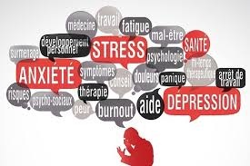

## Introduction

*Nous avons choisi de réaliser cette analyse sur R MarkDown qui est une fonctionnalité du logiciel R studio. Cette dernière permet, entres autres, d’éditer des rapports avec une syntaxe claire et lisible dans de nombreux formats comme HTML, Word ou encore PDF. L’évaluation de ce travail portant sur la connaissance du logiciel de programmation R studio, nous avons jugé pertinent de faire notre analyse en utilisant une fonctionnalité additionnelle de ce dernier.*

Saviez vous qu’en 2015 seulement 65% des salariés considéraient que leur travail était reconu à sa juste valeur ? Le manque de reconnaissance, ajouté au stress quotidien des employés, le harcèlement moral ainsi que la pression parfois exercée par les supérieurs hiérarchiques, peuvent avoir de fortes répercussions sur l’état de santé des individus. En réponse à cela, de nombreux organismes se sont créés pour prévenir les risques professionnels. Parmis ces organismes il existe : le conseil d’orientation des conditions de travail (COCT - 2008), l’agence européenne pour la santé et la sécurité au travail (OSHA - 1994), ou encore l’institut national de recherche et de sécurité pour la prévention des accidents du travail et des maladies professionnelles (INRS - 1947). L’amélioration des conditions de travail est devenue une priorité pour certaines entreprises, mais d’autres continuent de placer les profits avant l’Humain.

C’est pourquoi, dans cette étude nous essayerons de trouver les facteurs qui peuvent avoir une influence sur les conditions de travail, pour pouvoir à terme donner des explications plus claires et plus précises des composantes sur lesquelles il faudrait agir pour améliorer les journées des travailleurs.

Nous allons à présent nous concentrer sur l’explication de l’enquête afin de contextualiser de manière plus précise l’analyse que nous commencerons dès la deuxième partie. L’enquête dont nous nous sommes servies comme base de données est une enquête réalisée en 2015 par l’Institut National de la Statistique et des Études Économiques (INSEE) portant sur l’emploi sous toutes ses formes (activité, emploi, chômage). Cette “Enquête Emploi”, publiée pour la première fois en 1950 et tous les ans depuis, a été réalisée en France métropolitaine ainsi que dans les 4 départements d’outre-mer (ce depuis 2014). Elle s’effectue trimestriellement mais les personnes interrogées peuvent l’avoir étées en 2014, ou seulement au premier et deuxième trimestres par exemple ; tout cela est précisé dans la base. Pour cette étude nous utiliserons les données du premier semestre de 2015.

## 1- Création et nettoyage de la base

### 1.1 Sélection de variables

- La variable que nous avons choisi d’expliquer est la suivante (elle sera donc notre Y) :
  - **Appréciation personnelle de l’individu sur son état de santé général** (SANTGEN), cette variable est qualitative puisqu’elle prend 7 modalités : 1 “Très bon”, 2 “Bon”, 3 “Assez bon”, 4 “Mauvais”, 5 “Très mauvais”, 8 “Refus”, 9 “Ne sait pas”.
- Pour expliquer la santé générale des individus nous avons sélectionné 5 variables (qui seront nos X) :
  - **Sexe** (SEXE) : nous trouvions intéressant d’inclure cette variable afin de pouvoir noter l’existence ou non de différences entre les hommes et les femmes, la variable prend la valeur “1” s’il s’agit d’un homme, “2” sinon.
  - **Nombre de salariés dans l’entreprise** (NBSALA) : nous supposons que la taille de la structure peut influencer la pression et l’ambiance au travail exercées sur les employés par leurs supérieurs.
  - **Nombre de jour de travail par semaine** (JOURTR) : il est évident que le nombre d’heures passées à travailler a une influence forte sur l’état psychologique et physique de l’individu interrogé.
  - **Nombre d’heures supplémentaires effectuées dans une semaine** (EMPHNH) : de même, sachant que de telles heures sont prises sur le temps personnel d’une personne, il est intéressant de voir combien d’heures supplémentaires un français moyen effectu par semaine. Soit ses soirées soit ses week ends sont raccourcis, ce qui lui donne moins de temps pour se reposer et pratiquer des activités extérieures.
  - **Salarié qui voudrait travailler moins** (STMN), il s’agit d’une variable qualitative binaire qui prend la valeur “1” si la personne souhaite travailler moins même si cela induit une baisse de son revenu, “2” sinon.

### 1.2 Création de la base

- Avant toute opération nous appelons les **librairies** nécessaires à l’analyse :

```r
library(haven)
library(questionr)
library(outliers)
library(RColorBrewer)
library(tidyverse)
library(PerformanceAnalytics)
library(corrplot)
library(vcd)
library(car)
library(identity)
library(mfx)
library(nnet)
library(gmodels)
library(dplyr)
library(memisc)
```

- Nous importons la base issue du logiciel Stata, donc nous utilisons la commande “read_dta” :

```r
basetrim1 <- read_dta("INDIV151.R")
dim(basetrim1)
## [1] 110049    698
```

- Nous créons une nouvelle base ne contenant que les variables choisies précédemment :

```r
base <- basetrim1[ , c("santgen","sexe","nbsala","jourtr","empnbh","stmn")]
dim(base)
## [1] 110049      6
```

### 1.3 Nettoyage de la base

- Nous enlevons les observations pour lesquelles il manque des réponses, appelées “observations manquantes”. Pour ce faire il faut remplir les cases vides par des “NA” afin de pouvoir utiliser la fonction “na.omit”. Nous créons donc une nouvelle base *“base1”* débarassée des valeurs manquantes :

```r
base[base==""]=NA
base1=na.omit(base)
dim(base1)
## [1] 11130     6
110049-11130
## [1] 98919
```

Nous avons maintenant notre base finale que nous allons commencer par nettoyer pour analyser par la suite les conditions de travail sur la santé des travailleurs. Notre base est composée de 11.130 observations (soit 98.919 de moins que dans la base originale) et de 6 variables.

- Nous renommons les variables par des noms plus explicites que l’on choisit :

```r
names(base1)
## [1] "santgen" "sexe"    "nbsala"  "jourtr"  "empnbh"  "stmn"
base1<-rename.variable(base1,"santgen","Sante")
base1<-rename.variable(base1,"sexe","Sexe")
base1<-rename.variable(base1,"nbsala","Salariés")
base1<-rename.variable(base1,"jourtr","Jour_sem")
base1<-rename.variable(base1,"empnbh","HeureSup_sem")
base1<-rename.variable(base1,"stmn","Chgmt_h")
names(base1)
## [1] "Sante"        "Sexe"         "Salariés"     "Jour_sem"
## [5] "HeureSup_sem" "Chgmt_h"
```

- Nous supprimons la modalité *‘99’* de la variable “nbsala” (nombre de salariés) puisque cette modalité indique que la personne ayant répondu ne sait pas combien d’employés il y a dans l’entreprise. Nous enlevons cette modalité qui ne nous intéresse pas et qui empêche de considérer la variable comme quantitative :

```r
base1 <- base1[!base1$Salariés=="99", ]
dim(base1)
## [1] 10532     6
11130-10532
## [1] 598
```

En supprimant cette modalité nous obtenons une base de dimensions [10.532 ; 6], sur notre échantillon il y avait donc 598 personnes qui ne connaissaient pas le nombre de travailleurs dans leur entreprise.

```r
str(base1)
## Classes 'tbl_df', 'tbl' and 'data.frame':    10532 obs. of  6 variables:
##  $ Sante       : chr  "3" "1" "1" "1" ...
##  $ Sexe        : chr  "1" "1" "1" "2" ...
##  $ Salariés    : chr  "11" "10" "2" "11" ...
##  $ Jour_sem    : chr  "5.0" "5.0" "6.0" "6.0" ...
##  $ HeureSup_sem: chr  "37.0" "35.0" "38.0" "35.0" ...
##  $ Chgmt_h     : chr  "2" "2" "2" "2" ...
##  - attr(*, "na.action")= 'omit' Named int  2 3 4 5 7 8 10 11 12 14 ...
##   ..- attr(*, "names")= chr  "2" "3" "4" "5" ...
base1[,c(1,2,6)]=lapply(base1[,c(1,2,6)],as.factor)
base1[,c(3,4,5)]=lapply(base1[,c(3,4,5)],as.integer)
str(base1)
## Classes 'tbl_df', 'tbl' and 'data.frame':    10532 obs. of  6 variables:
##  $ Sante       : Factor w/ 7 levels "1","2","3","4",..: 3 1 1 1 2 2 2 3 3 2 ...
##  $ Sexe        : Factor w/ 2 levels "1","2": 1 1 1 2 2 2 1 2 1 1 ...
##  $ Salariés    : int  11 10 2 11 10 10 10 11 10 5 ...
##  $ Jour_sem    : int  5 5 6 6 5 5 4 5 5 6 ...
##  $ HeureSup_sem: int  37 35 38 35 35 40 35 27 35 24 ...
##  $ Chgmt_h     : Factor w/ 2 levels "1","2": 2 2 2 2 2 2 2 2 2 2 ...
##  - attr(*, "na.action")= 'omit' Named int  2 3 4 5 7 8 10 11 12 14 ...
##   ..- attr(*, "names")= chr  "2" "3" "4" "5" ...
```

Notre base étant créée et néttoyée nous pouvons à présent commencer une analyse plus technique de l’état de santé des travailleurs.

## 2- Analyse technique de l’état de santé

### 2.1 Statistiques descriptives

- Nous commencons par regarder les **statistiques préliminaires** de chaque variable :

```r
summary(base1)
##  Sante    Sexe        Salariés         Jour_sem      HeureSup_sem
##  1:3823   1:5350   Min.   : 1.000   Min.   :0.000   Min.   : 0.00
##  2:5092   2:5182   1st Qu.:10.000   1st Qu.:5.000   1st Qu.:35.00
##  3:1385            Median :11.000   Median :5.000   Median :36.00
##  4: 194            Mean   : 9.771   Mean   :4.857   Mean   :36.31
##  5:  18            3rd Qu.:11.000   3rd Qu.:5.000   3rd Qu.:40.00
##  8:   9            Max.   :12.000   Max.   :7.000   Max.   :99.00
##  9:  11
##  Chgmt_h
##  1:  301
##  2:10231
##
##
##
##
##
(194+18)/10532*100
## [1] 2.012913
5350/10532*100
## [1] 50.79757
301/10532*100
## [1] 2.857957
```

- Nous pouvons à présent regarder si nos variables sont homogènes ou hétérogènes en comparant **l’écart-type** avec la **moyenne** pour les variables quantitatives :

```r
round(sapply(base1[,c(3,4,5)],mean),2)
##     Salariés     Jour_sem HeureSup_sem
##         9.77         4.86        36.31
round(sapply(base1[,c(3,4,5)],sd),2)
##     Salariés     Jour_sem HeureSup_sem
##         2.64         0.69        10.27
```

Nous constatons d’après la sortie R ci-dessus que toutes nos variables sont homogènes puisque leur écart-type est plus faible que la moyenne, dans le cas contraire nous aurions parlé d’hétérogénéité des variables ; il aurait donc fallut les centrer et les réduire.

### 2.2 Analyse des variables explicatives

- La prochaine étape après cette analyse basique est de vérifier l’existence de valeurs potentiellement atypiques qui peuvent affecter nos résultats et biaiser nos estimations. Nous regardons cela grâce aux **diagrammes de Tukey**, aussi appelés “boîte à moustaches” ; les observations qui ne sont pas contenues dans la boîte sont considérées comme atypiques.

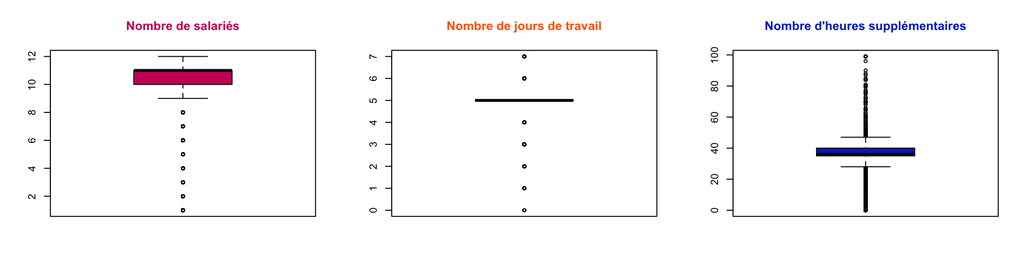

```r
par(mfrow=c(1,3))
boxplot(base1$`Salariés`, main="Nombre de salariés", col="#CC0066", col.main="#CC0066")
boxplot(base1$`Jour_sem`, main="Nombre de jours de travail", col="#FF6600", col.main="#FF6600")
boxplot(base1$`HeureSup_sem`, main="Nombre d'heures supplémentaires", col="#0033CC", col.main="#0033CC")
```

Il existe donc des valeurs potentiellement atypiques pour chacune des variables quantitatives que nous avons prises en compte dans notre analyse. La variable en contenant le plus est celle qui mesure le nombre d’heures supplémentaires éffectuées dans une semaine. Cela fait sens car dans la partie précédente qui consistait à regarder les statistiques descriptives des variables, nous avions vu que pour cette variable les valeurs étaient extrèmes (allant de 0 à 99), ce qui traduit une étendue très élevée. De ce fait, les résultats pourraient être biaisés, il faut donc rester vigilants quant à leur inteprétation dans cette analyse.

- Nous nous interessons maintenant aux **histogrammes** des variables quantitatives qui montrent la distribution de celles-ci, nous verrons ainsi si elles s’apparentent ou non à une loi normale.

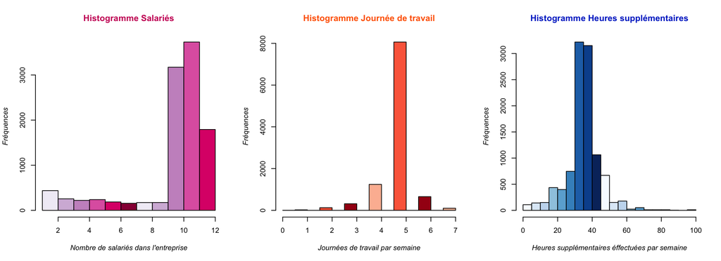

```r
par(mfrow=c(1,3))
hist(base1$Salariés, main="Histogramme Salariés", xlab="Nombre de salariés dans l'entreprise", ylab="Fréquences", col=brewer.pal(n = 6, name = "PuRd"), font.lab=3, col.main="#CC0066")
hist(base1$Jour_sem, main="Histogramme Journée de travail", xlab="Journées de travail par semaine", ylab="Fréquences", col=brewer.pal(n = 6, name = "Reds"), font.lab=3, col.main="#FF6600")
hist(base1$HeureSup_sem, main="Histogramme Heures supplémentaires", xlab="Heures supplémentaires éffectuées par semaine", ylab="Fréquences", col=brewer.pal(n = 9, name = "Blues"), font.lab=3, col.main="#0033CC")
```

À première vue il apparait que nos variables ne suivent pas une loi normale. En regardant l’histogramme de la variable “Salariés”, nous remarquons une forte asymétrie négative (c’est à dire à droite), nous constatons aussi que la plupart des entreprises ont un nombre d’employés supérieur à 10, modalités pour lesquelles les “barres” de l’histogramme sont très grandes. Nous notons que la variable “Jour_sem” a une asymétrie négative, la plus grande fréquence d’apparition est de 8000 individus pour 5 jours travaillés. Finalement, notre variable “HeureSup_sem” est celle qui s’approche le plus de la distribution normale, il y a cependant une légère asymétrie à gauche (donc asymétrie positive).

- Finalement nous regardons les **graphiques de corrélation** entre les variables explicatives quantitatives et Y (évaluation personnelle de l’état de santé). Nous avons choisi de différencier les individus selon leur évaluation de santé en prenant comme code couleur la variable “Sante” :

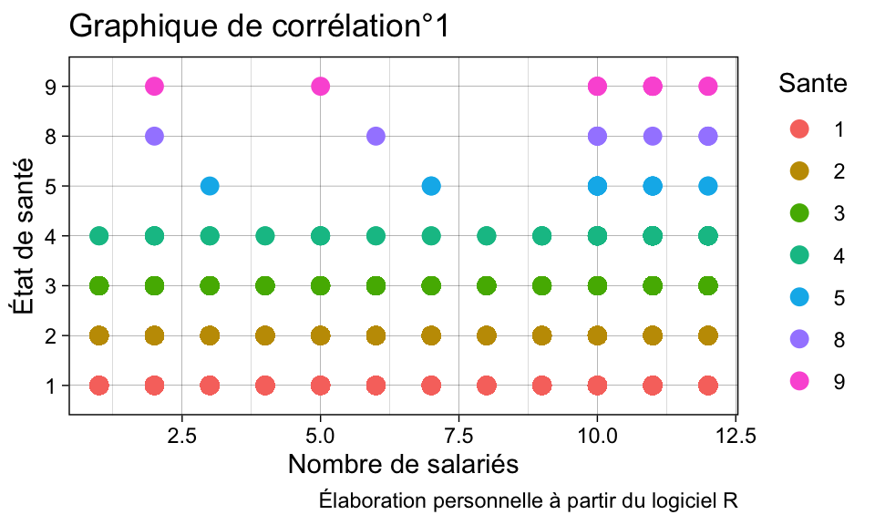

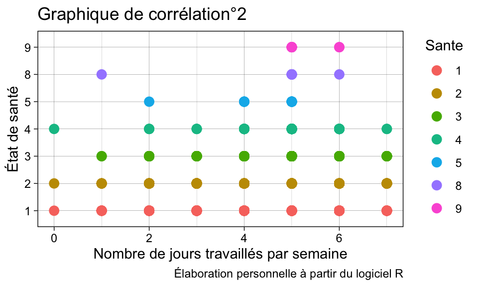

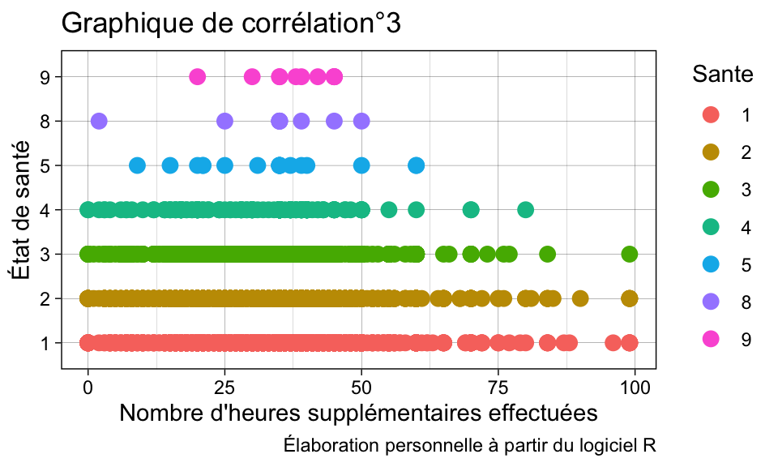

```r
df <- base1
par(mfrow=c(1,3))

p <- ggplot(data = df,mapping=aes(Salariés,Sante)) + geom_point(mapping=aes(Salariés,Sante, color=Sante), size=3) + geom_smooth(se=FALSE)
p + labs(title="Graphique de corrélation°1",
    caption="Élaboration personnelle à partir du logiciel R",
         x="Nombre de salariés",
         y="État de santé") +
         theme_linedraw()

p1 <- ggplot(data = df,mapping=aes(Jour_sem,Sante)) + geom_point(mapping=aes(Jour_sem,Sante, color=Sante), size=3) + geom_smooth(se=FALSE)
p1 + labs(title="Graphique de corrélation°2",
    caption="Élaboration personnelle à partir du logiciel R",
         x="Nombre de jours travaillés par semaine",
         y="État de santé") +
         theme_linedraw()

p2 <- ggplot(data = df,mapping=aes(HeureSup_sem,Sante)) + geom_point(mapping=aes(HeureSup_sem,Sante, color=Sante), size=3) + geom_smooth(se=FALSE)
p2 + labs(title="Graphique de corrélation°3",
    caption="Élaboration personnelle à partir du logiciel R",
         x="Nombre d'heures supplémentaires effectuées",
         y="État de santé") +
         theme_linedraw()
```

D’après les graphiques ci-dessus nous remarquons que les personnes qui estiment être en bonne santé (modalités 1 et 2) ont des réponses très hétérogènes puisque leurs jours de travail vont de 1 à 7 avec des individus pour chaque cas, contrairement aux individus qui estiment avoir une mauvaise santé (modalité n°5) où l’on constate qu’il y a seulement des travailleurs de 2 à 5 jours. De même, le graphique de corrélation n°3 montre que les personnes ne sachant pas répondre à l’évaluation de leur état de santé sont des personnes qui effectuent des heures supplémentaires entre 20 et 45 heures environ, donc l’étendue est plus faible pour cette catégorie.

- Nous pouvons terminer cette analyse des variables quantitatives en regardant la corrélation, c’est à dire le lien qu’il existe entre ces 3 variables. Pour cela nous regardons la **matrice de corrélation** :

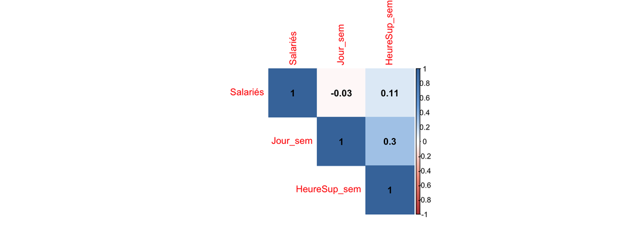

```r
cor <- cor(base1[,c(3,4,5)],use="complete.obs",method=c("spearman"))
cor
##                 Salariés    Jour_sem HeureSup_sem
## Salariés      1.00000000 -0.02657449    0.1065623
## Jour_sem     -0.02657449  1.00000000    0.2952773
## HeureSup_sem  0.10656231  0.29527733    1.0000000
library(corrplot)
col <- colorRampPalette(c("#BB4444", "#EE9988", "#FFFFFF", "#77AADD", "#4477AA"))
corrplot(cor, method="color", col=col(200),
             type="upper",
             addCoef.col = "black")
```

En regardant la matrice de corrélation et le graphique de corrélation ( “Chart Correlation” disponible en annexe n°1), nous constatons l’existence de faibles corrélations entre les différentes variables explicatives. Nous constatons une corrélation négative très faible entre le nombre de Salariés et le nombre de jours de travail pendant la semaine. Cela signifie que ces deux variables varient dans un sens inverse ; plus il y a de salariés dans l’entreprise, meilleure sera la répartition du travail et donc moins les salariés travailleront (baisse du nombre de jours de travail par semaine). En revanche, la corrélation entre le nombre de salariés et le nombre d’heures supplémentaires de travail est positive mais elle reste relativement faible. Enfin, la corrélation est positive et modérée (coefficient de corrélation=0,30) entre le nombre de jours de travail par semaine et le nombre d’heures supplémentaires. C’est tout à fait logique ; si le nombre de jours de travail par semaine augmente, c’est à dire s’il dépasse les 5 jours réglementaires à 35 heures la semaine, alors le nombre d’heures supplémentaires augmentera aussi.

### 2.3 Analyse des variables explicatives par rapport à l’état de santé

- Il convient à présent d’analyser les variables qualitatives par rapport à notre variable à expliquer “Sante”. Étant qualitatives, nous ne pouvons les analyser de la même manière que les précédentes (à l’aide d’histogrammes et de boxplots), en revanche nous pouvons établir un **croisement** entre celles-ci et l’état de santé :

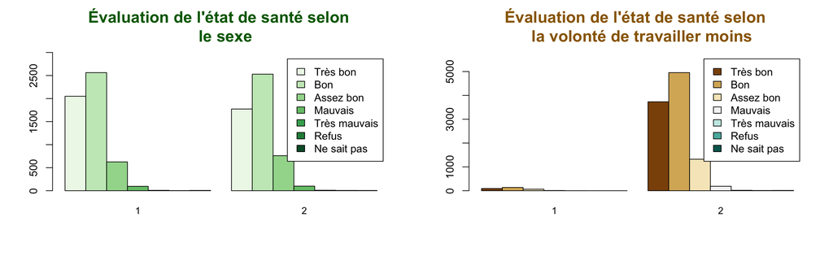

```r
t1=table(base1$Sante, base1$Sexe)
t2=table(base1$Sante, base1$Chgmt_h)

par(mfrow=c(1,2))
barplot(t1, beside=T, ylim=c(0,3000), legend.text=c("Très bon", "Bon", "Assez bon", "Mauvais", "Très mauvais", "Refus", "Ne sait pas"), main="Évaluation de l'état de santé selon
  le sexe", col=brewer.pal(n = 7, name = "Greens"), cex.names=.9, cex.main=1.5, col.main="#006600")
barplot(t2, beside=T, ylim=c(0,5800), legend.text=c("Très bon", "Bon", "Assez bon", "Mauvais", "Très mauvais", "Refus", "Ne sait pas"), main="Évaluation de l'état de santé selon
  la volonté de travailler moins", col=brewer.pal(n = 7, name = "BrBG"), cex.names=.9, cex.main=1.5, col.main="#996600")
```

Les barplots des variables qualitatives et les tableaux croisés disponibles en annexe n°2 nous montrent les différences sur l’évaluation de la santé en fonction du sexe de la personne interrogée ainsi que sa volonté de faire moins d’heures de travail (mesurée par la variable binaire “Chgmt_h”). Nous voyons directement que dans notre échantillon le nombre d’hommes (modalité n°1 de la variable “Sexe”) se considérant en très bonne santé est plus élevée que chez les femmes (modalité n°2) lorsque nous regardons la première *barre* du barplot de gauche. Telle est la principale différence que l’on observe en comparant les hommes et les femmes, on peut noter aussi que les deux catégories se considèrent généralement en bonne santé puisque les effectifs sont concentrés vers les 3 permières modalités qui vont de “très bon” à “assez bon” état de santé. Si nous regardons le barplot de droite qui croise la variable à expliquer Y avec la variable “Chgmt_h” qui prend la modalité n°1 si la personne interrogée souhaite diminuer son temps de travail et la modalité n°2 si non, nous voyons que la plupart des personnes semblent satisfaites de leurs horaires de travail. Nous avions déjà fait un tel constat en regardant les statistiques descritpives de cette variable en partie 2.1. Dans les personnes qui ne souhaitent par réduire le nombre d’heures de travail nous voyons que la plus grande partie se considère en “bon état” de santé (modalité n°2 de Y).

- Après avoir croisé deux variables qualitatives nous pouvons aussi **croiser des variables quantitatives avec une qualitative** ; nous deçidons de croiser Y (évaluation de l’état de santé) avec les 3 variables quantitatives. Nous obtenons ainsi :

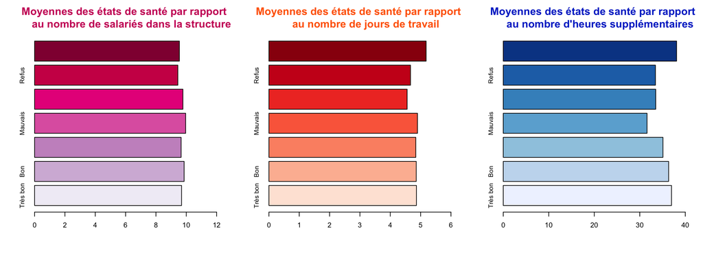

```r
t3=tapply(base1$Salariés, base1$Sante, mean)
t4=tapply(base1$Jour_sem, base1$Sante, mean)
t5=tapply(base1$HeureSup_sem, base1$Sante, mean)

par(mfrow=c(1,3))
barplot(t3, horiz=TRUE,xlim=c(0,12),names.arg=c("Très bon", "Bon", "Assez bon", "Mauvais", "Très mauvais", "Refus", "Ne sait pas"), main="Moyennes des états de santé par rapport
    au nombre de salariés dans la structure", col=brewer.pal(n = 7, name = "PuRd"), cex.names=.9, cex.main=1.5, col.main="#CC0066")
barplot(t4, horiz=TRUE,xlim=c(0,6),names.arg=c("Très bon", "Bon", "Assez bon", "Mauvais", "Très mauvais", "Refus", "Ne sait pas"), main="Moyennes des états de santé par rapport
    au nombre de jours de travail", col=brewer.pal(n = 7, name = "Reds"), cex.names=.9, cex.main=1.5, col.main="#FF6600")
barplot(t5, horiz=TRUE,xlim=c(0,40),names.arg=c("Très bon", "Bon", "Assez bon", "Mauvais", "Très mauvais", "Refus", "Ne sait pas"), main="Moyennes des états de santé par rapport
    au nombre d'heures supplémentaires", col=brewer.pal(n = 7, name = "Blues"), cex.names=.9, cex.main=1.5, col.main="#0033CC")
```

Les barplots ci-dessus et les tableaux croisés disponibles en annexe n°3 nous informe qu’en moyenne le nombre de salariés, de jours de travail et d’heures supplémentaires n’ont pas un impact très important sur l’évaluation que chaque individu fait de son état de santé. En effet on voit que les barres des barplots sont de tailles plus ou moins égales surtout pour les 2 premiers. Prenons l’exemple du nombre d’heures supplémentaires éffectuées dans une semaine : les employés qui travaillent 36 heures de plus par semaine sont en bonne santé, en revanche, les salariés qui travaillent moins d’heures supplémentaires se considèrent en mauvaise santé. Ce peut être vérifié parce qu’un individu en bonne santé peut travailler davantage qu’un individu se considérant en mauvaise santé, justement parce que son état de santé dégradé l’empêche de travailler plus. Cependant, ces représentations graphiques ne nous donnent pas suffisamment d’informations pour conclure de manière exacte, nous allons donc compléter cette analyse en établissant des modèles de régression logistique qui nous donneront une information plus précise quant aux variables qui sont censées expliquer l’évaluation de l’état des santé. En effet ces régressions nous diront quelles variables sont significatives (donc si elles ont un réel impact sur Y) et de combien sont leur coefficient estimé (c’est à dire quel lien -positif ou négatif- il existe entre telle variable et Y).

## 3- Régressions logistiques

### 3.1 Régression logistique multinomiale

- Nous rappelons que la variable que nous tentons d’expliquer est celle de l’évaluation personnelle de chaque individu sur son état de santé. Cette variable est qualitative puisqu’elle prend plusieurs modalités (allant de “très bonne appréciation” à “ne sait pas”). Pour l’expliquer au mieux nous allons effectuer une régression, dans notre cas nous allons appliquer la **régression logistique multinomiale** :

```r
modele=multinom(formula=Sante ~ Sexe +Salariés +Jour_sem +HeureSup_sem +Chgmt_h, data=base1)
summary(modele)
```

[output not shown]

```r
exp(0.12)
## [1] 1.127497
exp(0.03)
## [1] 1.030455
exp(-0.01)
## [1] 0.9900498
exp(0.08)
## [1] 1.083287
exp(-0.66)
## [1] 0.5168513
exp(0.06)
## [1] 1.061837
```

Finalement, nous nous interessons à la modalité n°4 de Y, c’est à dire ‘mauvais état de santé’, pour laquelle toutes les variables sont significatives sauf les variables qualitatives ‘Sexe’ et ‘Chgmt_h’. Nous voyons par exemple que la probabilité pour un individu d’avoir un **mauvais** état de santé, sera 1,06 fois supérieure pour une personne qui travaille dans une entreprise où il y a beaucoup de salariés. Cela fait sens que la santé des travailleurs se déteriore lorsque la structure de travail s’aggrandit puisqu’alors, la firme gère plus de problèmes, il y a davantage de stress et de pression, ce qui peut affecter la santé des individus.

### 3.2 Régression logistique binaire

- Après avoir effectué une régression logistique multinomiale nous decidons de réaliser une régression logistique binaire afin de comparer les résultats obtenus avec ceux du modèle précedent. Pour cela nous recodons les variables : nous passons “très bon”, “bon” et “assez bon” en une seule modalité qui correspond à un **bon état de santé**, nous passons les 4 autres en une deuxième modalité qui correspond à un **mauvais santé** ou simplement le fait de **ne pas savoir** :

```r
base1$Bon=fct_recode(base1$Sante, 'c(1,2,3)=0; c(4,5,8,9)=1')
```

- Nous pouvons à présent appliquer la régression logistique binaire de 2 manières différentes par un modèle **logit** que l’on nommera “modele2”, puis par un modèle **probit** que l’on nommera “modele3” :

```r
modele2=glm(Bon ~ Sexe+Salariés+Jour_sem+HeureSup_sem+Chgmt_h, family=binomial("logit"), data=base1)
summary(modele2)
##
## Call:
## glm(formula = Bon ~ Sexe + Salariés + Jour_sem + HeureSup_sem +
##     Chgmt_h, family = binomial("logit"), data = base1)
##
## Deviance Residuals:
##     Min       1Q   Median       3Q      Max
## -1.6973  -1.3884   0.9044   0.9671   1.2690
##
## Coefficients:
##               Estimate Std. Error z value Pr(>|z|)
## (Intercept)   0.621389   0.213231   2.914 0.003566 **
## Sexe2         0.148264   0.041769   3.550 0.000386 ***
## Salariés      0.022852   0.007651   2.987 0.002820 **
## Jour_sem      0.055763   0.032069   1.739 0.082067 .
## HeureSup_sem -0.010202   0.002174  -4.693  2.7e-06 ***
## Chgmt_h2     -0.260094   0.127165  -2.045 0.040822 *
## ---
## Signif. codes:  0 '***' 0.001 '**' 0.01 '*' 0.05 '.' 0.1 ' ' 1
##
## (Dispersion parameter for binomial family taken to be 1)
##
##     Null deviance: 13799  on 10531  degrees of freedom
## Residual deviance: 13747  on 10526  degrees of freedom
## AIC: 13759
##
## Number of Fisher Scoring iterations: 4

modele3=glm(Bon ~ Sexe+Salariés+Jour_sem+HeureSup_sem+Chgmt_h, family=binomial("probit"), data=base1)
summary(modele3)
##
## Call:
## glm(formula = Bon ~ Sexe + Salariés + Jour_sem + HeureSup_sem +
##     Chgmt_h, family = binomial("probit"), data = base1)
##
## Deviance Residuals:
##     Min       1Q   Median       3Q      Max
## -1.7029  -1.3882   0.9043   0.9672   1.2658
##
## Coefficients:
##               Estimate Std. Error z value Pr(>|z|)
## (Intercept)   0.383158   0.130530   2.935 0.003331 **
## Sexe2         0.091498   0.025714   3.558 0.000373 ***
## Salariés      0.014099   0.004735   2.978 0.002904 **
## Jour_sem      0.034959   0.019705   1.774 0.076046 .
## HeureSup_sem -0.006323   0.001336  -4.734  2.2e-06 ***
## Chgmt_h2     -0.158730   0.076967  -2.062 0.039178 *
## ---
## Signif. codes:  0 '***' 0.001 '**' 0.01 '*' 0.05 '.' 0.1 ' ' 1
##
## (Dispersion parameter for binomial family taken to be 1)
##
##     Null deviance: 13799  on 10531  degrees of freedom
## Residual deviance: 13747  on 10526  degrees of freedom
## AIC: 13759
##
## Number of Fisher Scoring iterations: 4
```

## 4- Annexes

- Annexe n°1 : **Chart Correlation** des variables quantitatives

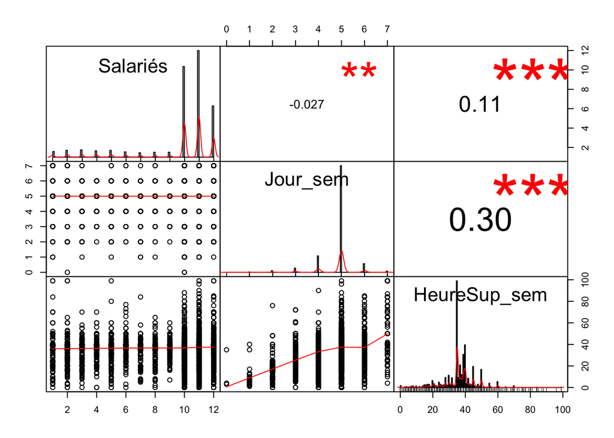

```r
mydata <- base1[, c("Salariés", "Jour_sem", "HeureSup_sem")]
chart.Correlation(mydata, histogram=TRUE, pch=19,method = c("spearman"))
```

- Annexe n°2 : **Tableaux croisés** de la variable ‘Sante’ avec les variables **qualitatives** et analyse complémentaire (pourcentages par lignes, colonnes, et globaux des tableaux de fréquences bidirectionnels)

```r
t1
##
##        1    2
##   1 2050 1773
##   2 2563 2529
##   3  625  760
##   4   95   99
##   5    8   10
##   8    3    6
##   9    6    5
t2
##
##        1    2
##   1   92 3731
##   2  137 4955
##   3   63 1322
##   4    8  186
##   5    1   17
##   8    0    9
##   9    0   11

cprop(t1)
##
##         1     2     Ensemble
##   1      38.3  34.2  36.3
##   2      47.9  48.8  48.3
##   3      11.7  14.7  13.2
##   4       1.8   1.9   1.8
##   5       0.1   0.2   0.2
##   8       0.1   0.1   0.1
##   9       0.1   0.1   0.1
##   Total 100.0 100.0 100.0
rprop(t1)
##
##            1     2     Total
##   1         53.6  46.4 100.0
##   2         50.3  49.7 100.0
##   3         45.1  54.9 100.0
##   4         49.0  51.0 100.0
##   5         44.4  55.6 100.0
##   8         33.3  66.7 100.0
##   9         54.5  45.5 100.0
##   Ensemble  50.8  49.2 100.0
prop(t1, percent=TRUE)
##
##         1      2      Total
##   1      19.5%  16.8%  36.3%
##   2      24.3%  24.0%  48.3%
##   3       5.9%   7.2%  13.2%
##   4       0.9%   0.9%   1.8%
##   5       0.1%   0.1%   0.2%
##   8       0.0%   0.1%   0.1%
##   9       0.1%   0.0%   0.1%
##   Total  50.8%  49.2% 100.0%

cprop(t2)
##
##         1     2     Ensemble
##   1      30.6  36.5  36.3
##   2      45.5  48.4  48.3
##   3      20.9  12.9  13.2
##   4       2.7   1.8   1.8
##   5       0.3   0.2   0.2
##   8       0.0   0.1   0.1
##   9       0.0   0.1   0.1
##   Total 100.0 100.0 100.0
rprop(t2)
##
##            1     2     Total
##   1          2.4  97.6 100.0
##   2          2.7  97.3 100.0
##   3          4.5  95.5 100.0
##   4          4.1  95.9 100.0
##   5          5.6  94.4 100.0
##   8          0.0 100.0 100.0
##   9          0.0 100.0 100.0
##   Ensemble   2.9  97.1 100.0
prop(t2, percent=TRUE)
##
##         1      2      Total
##   1       0.9%  35.4%  36.3%
##   2       1.3%  47.0%  48.3%
##   3       0.6%  12.6%  13.2%
##   4       0.1%   1.8%   1.8%
##   5       0.0%   0.2%   0.2%
##   8       0.0%   0.1%   0.1%
##   9       0.0%   0.1%   0.1%
##   Total   2.9%  97.1% 100.0%
```

- Annexe n°3 : **Tableaux croisés** de la variable ‘Sante’ avec les variables **quantitatives**

```r
t3
##        1        2        3        4        5        8        9
## 9.688988 9.857031 9.659928 9.958763 9.777778 9.444444 9.545455
t4
##        1        2        3        4        5        8        9
## 4.862150 4.856441 4.841155 4.896907 4.555556 4.666667 5.181818
t5
##        1        2        3        4        5        8        9
## 36.96756 36.33621 35.09242 31.59794 33.50000 33.44444 38.09091
```

- Annexe n°4 : Analyse complémentaire des variables ; **tableaux de fréquence**

```r
freq(base1$Sante)
##      n    % val%
## 1 3823 36.3 36.3
## 2 5092 48.3 48.3
## 3 1385 13.2 13.2
## 4  194  1.8  1.8
## 5   18  0.2  0.2
## 8    9  0.1  0.1
## 9   11  0.1  0.1
freq(base1$Sexe)
##      n    % val%
## 1 5350 50.8 50.8
## 2 5182 49.2 49.2
freq(base1$Salariés)
##       n    % val%
## 1   198  1.9  1.9
## 2   239  2.3  2.3
## 3   255  2.4  2.4
## 4   221  2.1  2.1
## 5   238  2.3  2.3
## 6   186  1.8  1.8
## 7   156  1.5  1.5
## 8   172  1.6  1.6
## 9   173  1.6  1.6
## 10 3172 30.1 30.1
## 11 3730 35.4 35.4
## 12 1792 17.0 17.0
freq(base1$Jour_sem)
##      n    % val%
## 0    3  0.0  0.0
## 1   24  0.2  0.2
## 2  126  1.2  1.2
## 3  316  3.0  3.0
## 4 1244 11.8 11.8
## 5 8062 76.5 76.5
## 6  656  6.2  6.2
## 7  101  1.0  1.0
freq(base1$HeureSup_sem)
##       n    % val%
## 0    50  0.5  0.5
## 1     2  0.0  0.0
## 2     5  0.0  0.0
## 3    17  0.2  0.2
## 4    20  0.2  0.2
## 5    14  0.1  0.1
## 6    17  0.2  0.2
## 7    34  0.3  0.3
## 8    38  0.4  0.4
## 9    14  0.1  0.1
## 10   38  0.4  0.4
## 11    7  0.1  0.1
## 12   24  0.2  0.2
## 13   10  0.1  0.1
## 14   39  0.4  0.4
## 15   70  0.7  0.7
## 16   66  0.6  0.6
## 17   83  0.8  0.8
## 18   79  0.8  0.8
## 19   27  0.3  0.3
## 20  180  1.7  1.7
## 21   95  0.9  0.9
## 22   51  0.5  0.5
## 23   33  0.3  0.3
## 24  139  1.3  1.3
## 25   80  0.8  0.8
## 26   58  0.6  0.6
## 27   69  0.7  0.7
## 28  260  2.5  2.5
## 29   43  0.4  0.4
## 30  316  3.0  3.0
## 31   80  0.8  0.8
## 32  254  2.4  2.4
## 33   58  0.6  0.6
## 34   59  0.6  0.6
## 35 2769 26.3 26.3
## 36  265  2.5  2.5
## 37  587  5.6  5.6
## 38  333  3.2  3.2
## 39  859  8.2  8.2
## 40 1108 10.5 10.5
## 41  106  1.0  1.0
## 42  241  2.3  2.3
## 43   92  0.9  0.9
## 44   76  0.7  0.7
## 45  548  5.2  5.2
## 46   46  0.4  0.4
## 47   36  0.3  0.3
## 48   84  0.8  0.8
## 49   33  0.3  0.3
## 50  470  4.5  4.5
## 51    3  0.0  0.0
## 52   18  0.2  0.2
## 53    8  0.1  0.1
## 54   12  0.1  0.1
## 55  110  1.0  1.0
## 56   14  0.1  0.1
## 57    2  0.0  0.0
## 58    6  0.1  0.1
## 59    2  0.0  0.0
## 60  154  1.5  1.5
## 61    2  0.0  0.0
## 62    2  0.0  0.0
## 63    1  0.0  0.0
## 64    1  0.0  0.0
## 65   17  0.2  0.2
## 66    1  0.0  0.0
## 68    2  0.0  0.0
## 69    2  0.0  0.0
## 70   46  0.4  0.4
## 72    5  0.0  0.0
## 73    1  0.0  0.0
## 75    5  0.0  0.0
## 76    2  0.0  0.0
## 77    2  0.0  0.0
## 79    1  0.0  0.0
## 80    6  0.1  0.1
## 81    1  0.0  0.0
## 84    9  0.1  0.1
## 85    1  0.0  0.0
## 87    1  0.0  0.0
## 88    1  0.0  0.0
## 90    1  0.0  0.0
## 96    1  0.0  0.0
## 99   10  0.1  0.1
freq(base1$Chgmt_h)
##       n    % val%
## 1   301  2.9  2.9
## 2 10231 97.1 97.1
```